# DL_project slides

# Loss Function:

To optimize our task, we need to define a loss function(cost or objective function) for this task. In logistic regression, we use the log-likelihood loss function.

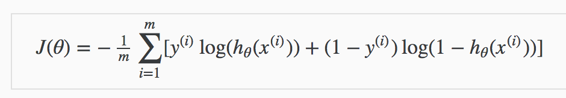

# Cost Function:

logarithmic function to represent the cost of logistic regression.

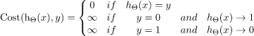

# Gradient Descent:

Minimizing the Cost with Gradient Descent

# Properties of Logistic Regression:

1) The dependent variable in logistic regression follows Bernoulli Distribution.  
2) Estimation is done through maximum likelihood.  
3) No R Square, Model fitness is calculated through Concordance, KS-Statistics

```
              precision    recall  f1-score   support

           0       0.83      0.82      0.83     40100
           1       0.82      0.84      0.83     39900

    accuracy                           0.83     80000
   macro avg       0.83      0.83      0.83     80000
weighted avg       0.83      0.83      0.83     80000
```

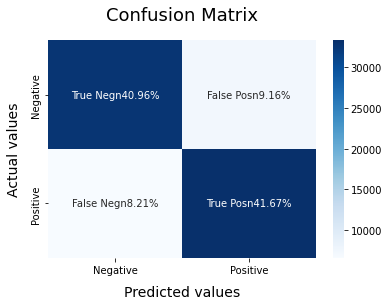

```python
LRmodel = LogisticRegression(C = 2, max_iter = 1000, n_jobs=-1)
LRmodel.fit(X_train, y_train)
model_Evaluate(LRmodel)
y_pred3 = LRmodel.predict(X_test)
```

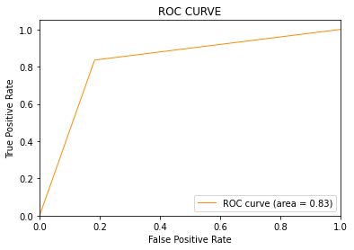

```python
ROC(y_test,y_pred3)
```

# Neural network

```python
y = df['target']
```

```python
df['target'].unique()
```

```
array([0, 1])
```

```python
df_train,df_test,y_train,y_test=train_test_split(df['text'],y,test_size=0.15,random_state=42)
print('DF Train Shape: ',df_train.shape)
print('DF Test Shape: ',df_test.shape)
print('Y Train Shape: ',y_train.shape)
print('Y Test Shape: ',y_test.shape)
```

```
DF Train Shape:  (1360000,)
DF Test Shape:  (240000,)
Y Train Shape:  (1360000,)
Y Test Shape:  (240000,)
```

# Implementing NLP (Natural language processing)

## tokenizer.fit_on_texts( )

fit_on_texts Updates internal vocabulary based on a list of texts. This method creates the vocabulary index based on word frequency

## tokenizer.texts_to_sequences( )

This class allows to vectorize a text corpus, by turning each text into either a sequence of integers (each integer being the index of a token in a dictionary) or into a vector where the coefficient for each token could be binary, based on word count, based on tf-idf

By default, all punctuation is removed, turning the texts into space-separated sequences of words (words maybe include the ' character). These sequences are then split into lists of tokens. They will then be indexed or vectorized.

```python
#Tokenizer
max_words = 10000
tokenizer = Tokenizer(max_words)
tokenizer.fit_on_texts(df_train)
train_sequence = tokenizer.texts_to_sequences(df_train)
test_sequence = tokenizer.texts_to_sequences(df_test)
```

## word_index

texts_to_sequences Transforms each text in texts to a sequence of integers. So it basically takes each word in the text and replaces it with its corresponding integer value from the word_index dictionary.

```python
#Independent tokens
token_index = tokenizer.word_index
V=len(token_index)
print('dataset has %s number of independent tokens' %V)
```

```
dataset has 619570 number of independent tokens
```

## pad_sequences( )

This function transforms a list (of length num_samples ) of sequences (lists of integers) into a 2D Numpy array of shape (num_samples, num_timesteps) . num_timesteps is either the maxlen argument if provided, or the length of the longest sequence in the list.  
the data are sized by inserting zeros in the list.

[figure not shown]

```python
#Transforming sequence of list to 2D Numpy array
data_train=pad_sequences(train_sequence)
data_train.shape
```

```
(1360000, 116)
```

```python
T=data_train.shape[1]
data_test=pad_sequences(test_sequence,maxlen=T)
data_test.shape
```

```
(240000, 116)
```

```python
data_train[0]
```

```
array([   0,    0,    0,    0,    0,    0,    0,    0,    0,    0,    0,
          0,    0,    0,    0,    0,    0,    0,    0,    0,    0,    0,
          0,    0,    0,    0,    0,    0,    0,    0,    0,    0,    0,
          0,    0,    0,    0,    0,    0,    0,    0,    0,    0,    0,
          0,    0,    0,    0,    0,    0,    0,    0,    0,    0,    0,
          0,    0,    0,    0,    0,    0,    0,    0,    0,    0,    0,
          0,    0,    0,    0,    0,    0,    0,    0,    0,    0,    0,
          0,    0,    0,    0,    0,    0,    0,    0,    0,    0,    0,
          0,    0,    0,    0,    0,    0,    0,    0,    0,   20,  388,
         45,   88,    2, 3260,   11, 6474,   42,  643,  162,   21,  256,
          6,    5,   51,    8,  630,  623], dtype=int32)
```

# Model Layers:

[figure not shown]

## Embedding

An embedding is a relatively low-dimensional space into which you can translate high-dimensional vectors. Embeddings make it easier to do machine learning on large inputs like sparse vectors representing words. Ideally, an embedding captures some of the semantics of the input by placing semantically similar inputs close together in the embedding space. An embedding can be learned and reused across models.

## Conv1D

A 1-D convolutional layer applies sliding convolutional filters to 1-D input. The layer convolves the input by moving the filters along the input and computing the dot product of the weights and the input, then adding a bias term.

## GlobalMaxPooling1D

A 1-D global max pooling layer performs downsampling by outputting the maximum of the time or spatial dimensions of the input.

## Dense

Dense Layer is simple layer of neurons in which each neuron receives input from all the neurons of previous layer, thus called as dense.

```python
D = 20
model = keras.Sequential()
model.add(layers.Input(T,))
model.add(layers.Embedding(V+1,D))
model.add(layers.Conv1D(32,3,activation='relu'))
model.add(layers.MaxPooling1D(3))
model.add(layers.Conv1D(64,3,activation='relu'))
model.add(layers.MaxPooling1D(3))
model.add(layers.Conv1D(128,3,activation='relu'))
model.add(layers.GlobalMaxPooling1D())
model.add(layers.Dense(2,activation='softmax'))
model.summary()
```

```
Model: "sequential_5"
_________________________________________________________________
 Layer (type)                Output Shape              Param #
=================================================================
 embedding_5 (Embedding)     (None, 116, 20)           12391420

 conv1d_15 (Conv1D)          (None, 114, 32)           1952

 max_pooling1d_10 (MaxPoolin  (None, 38, 32)           0
 g1D)

 conv1d_16 (Conv1D)          (None, 36, 64)            6208

 max_pooling1d_11 (MaxPoolin  (None, 12, 64)           0
 g1D)

 conv1d_17 (Conv1D)          (None, 10, 128)           24704

 global_max_pooling1d_5 (Glo  (None, 128)              0
 balMaxPooling1D)

 dense_5 (Dense)             (None, 2)                 258

=================================================================
Total params: 12,424,542
Trainable params: 12,424,542
Non-trainable params: 0
_________________________________________________________________
```

## Loss Function: sparse_categorical_crossentropy

sparse_categorical_crossentropy: Used as a loss function for multi-class classification model where the output label is assigned integer value (0, 1, 2, 3…). This loss function is mathematically same as the categorical_crossentropy.

## Optimizer: Adam

The name adam is derived from adaptive moment estimation. This optimization algorithm is a further extension of stochastic gradient descent to update network weights during training.  
the algorithm is straightforward to implement, has faster running time, low memory requirements, and requires less tuning than any other optimization algorithm.

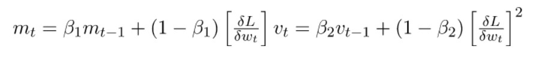

## Batch_size:

```python
model.compile(loss='sparse_categorical_crossentropy',optimizer='adam',metrics=['accuracy'])
cnn_senti=model.fit(data_train,y_train,validation_data=(data_test,y_test),epochs=7,batch_size=100)
```

```python
y_pred4=model.predict(data_test)
y_pred4
```

```
array([[0.40563187, 0.59436816],
       [0.7241496 , 0.27585045],
       [0.49277452, 0.50722545],
       ...,
       [0.7341435 , 0.26585647],
       [0.04407734, 0.9559227 ],
       [0.9210318 , 0.07896823]], dtype=float32)
```

## np.argmax( )

The numpy.argmax() function returns indices of the max element of the array in a particular axis.  
“axis 1” represents columns and "axis 0" represents rows.

```python
y_pred4=np.argmax(y_pred4,axis=1)
y_pred4
```

```
array([1, 0, 1, ..., 0, 1, 0])
```

```python
np.unique(y_pred4)
```

```
array([0, 1])
```

```python
np.unique(y_test)
```

```
array([0, 1])
```

[figure not shown]

```python
cm=confusion_matrix(y_test,y_pred4)
ax=sns.heatmap(cm,annot=True,cmap='Blues',fmt=' ')
ax.set_title('Confusion Matrix')
ax.set_xlabel('y_test')
ax.set_ylabel('y_pred')
```

```python
print(classification_report(y_test,y_pred4))
```

```
              precision    recall  f1-score   support

           0       0.81      0.84      0.82    119825
           1       0.83      0.80      0.82    120175

    accuracy                           0.82    240000
   macro avg       0.82      0.82      0.82    240000
weighted avg       0.82      0.82      0.82    240000
```

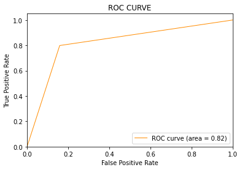

```python
ROC(y_test,y_pred4)
```

```python
!pip install RISE
```

[output not shown]